# “Week 4 Course Project Developing Data Products”

June 11th, 2019

## OBJECTIVES

The main purporse of this application is to show the a clustering algorithm, in particular K-Means Algorithm.

Through the app is it possible to understand how the number of instances change when the number of selected Cluster change. This is relevant because this algorithm is very sensitive to the number of clusters inout provided by the user.

## ASSUMPTIONS

In order to run the app, it is important to notice the following:

1. The iris data set was used
2. All the variables were used to perform the clustering (except the flower classification)
3. It was used the default method to calculate distances, Euclidean

## RESOURCES

The Shiny application is located in the following link:

https://chinrichsen.shinyapps.io/k-means_clustering_iris/

On the other side, the UI and Server code are located in the following link:

https://github.com/chinrichsen/kmeans_clustering_shinyapp

## EMBEDDED CODE AND PLOT

Below it is shown a plot considering 5 as the selected number of Clusters (the red horizontal line is the average number of instances by cluster).

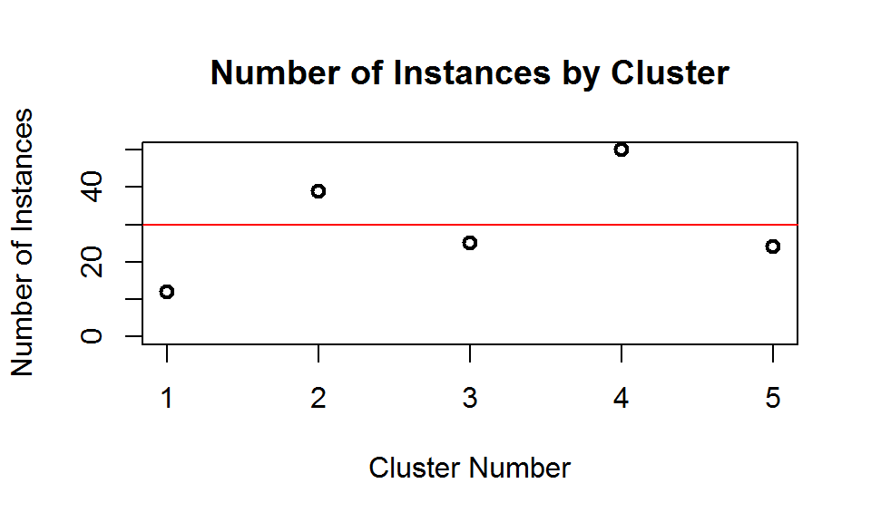

```r
tablec <- (table((data.frame(kmeans(iris[, -c(5)], 5)$cluster))))
plot(tablec,type = "p",main="Number of Instances by Cluster",
     xlab="Cluster Number", ylab="Number of Instances")
abline(h=150/5,col="red")
```